# A basic analysis: Visiting by Extraterrestrials

5/21/2021

==============================================================================

### **About**

**TERM PROJECT:** E.T. Explorer Shiny App

**title:** *A basic analysis: Visiting by Extraterrestrials*

**author:** Evrim Bilgen

### **aims&benefits**

The project aims at providing an accessible introduction to various R methods. That also taught me the understanding of interactive web applications. Even if I wanted more control of the application functionality understanding the key concepts was challenging. I came up with this idea regarding its proper and well-adjusted data form. And of course, being a fan of X-Files is another fact. I tried to build some histogram, graph, map visualization for our analyses.

### **materials&method**

- Writing own functions in R
- Advanced data processing with dplyr,dtplyr,tidyr
- Automation of scripts and reports (RMarkdown)

### **packages**

You can see our major packages below

```
* library(tidyverse)
* library(tidytext)
* library(shiny)
* library(dplyr)
* library(RSQLite)
* library(shinythemes)
* library(shinydashboard)
* library(shinyWidgets)
* library(shinyalert)
* library(DT)
* library(plotly)
* library(maps)
* library(leaflet)
* library(readr)
* library(ggplot2)
* library(RColorBrewer)
* library(markdown)
* library(knitr)
```

### **References**

- shiny.rstudio.com
- medium.com
- nielsvandervelden.com
- kaggle.com
- stackoverflow.com
- towardsdatascience.com
- Datacamp courses and case studies
- the National UFO Reporting Center
- bookdown.org
- nestacms.com/docs/creating-content/markdown-cheat-sheet
- jiashenliu.shinyapps.io/PokemonGo

[figure not shown]

## Let’s meet our data

Our data is provided by the National UFO Reporting Center including USA states.

```r
library(dplyr)
ET <- read.csv("./Data/ETdata.csv", header=TRUE)

glimpse(ET)
```

```
## Rows: 63,561
## Columns: 8
## $ date_sighted <chr> "1949-10-10", "1956-10-10", "1960-10-10", "1961-10-10", "…
## $ latitude     <dbl> 29.88306, 28.97833, 21.41806, 36.59500, 41.11750, 33.5861…
## $ longitude    <dbl> -97.94111, -96.64583, -157.80361, -82.18889, -73.40833, -…
## $ city         <chr> "San Marcos", "Edna", "Kaneohe", "Bristol", "Norwalk", "P…
## $ state        <chr> "TX", "TX", "HI", "TN", "CT", "AL", "FL", "CA", "NC", "NY…
## $ shape        <chr> "cylinder", "circle", "light", "sphere", "disk", "disk", …
## $ duration_sec <dbl> 2700, 20, 900, 300, 1200, 180, 120, 300, 180, 1800, 180, …
## $ comments     <chr> "This event took place in early fall around 1949-50. It o…
```

[output not shown]

Our first analysis tab includes first plot. And also there are two inputs, one button on the left side.

We built this structure using navbarpage including 3 tabpanels and their inputs

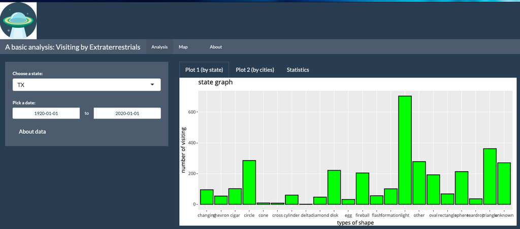

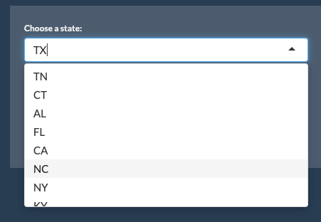

Our first plot is representing the number of visits as the type of shape depending on the state and date information.

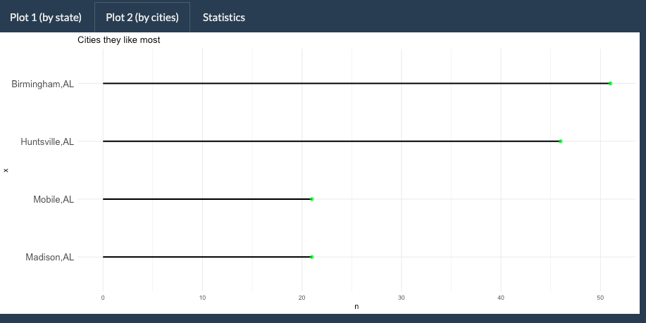

The second plot is presenting cities that UFO visited mostly in the chosen state.(above)

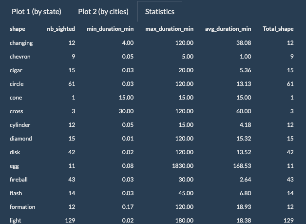

And the last tab is about general statistics information depending on the state and date information and some calculation about the shapes.

Here below, you can see basic calculations such as min, max, the average duration of the seeing shapes.

```r
ET %>%
      filter(
        state == 'AL',
        date_sighted >= '2010-01-01',
        date_sighted <= '2020-01-01'
      ) %>%
      group_by(shape) %>%
      summarize(
        nb_sighted = n(),
        min_duration_min = min(duration_sec) / 60,
        max_duration_min = max(duration_sec) / 60,
        avg_duration_min = mean(duration_sec) / 60,
        Total_shape = length(shape)
      )
```

```
## # A tibble: 19 × 6
##    shape     nb_sighted min_duration_min max_duration_min avg_duration_min
##    <chr>          <int>            <dbl>            <dbl>            <dbl>
##  1 changing           4           4                120              34.5
##  2 chevron            2           0.25               0.75            0.5
##  3 cigar              3           0.0833             5               2.36
##  4 circle            25           0.0333            75               9.52
##  5 cross              3          30                120              60
##  6 cylinder           7           0.5               15               6.64
##  7 diamond            7           0.0333             8               3.58
##  8 disk               4           0.167             25              13.3
##  9 egg                4           0.167              3               0.875
## 10 fireball          21           0.0667            30               3.49
## 11 flash              8           0.0333            45               8.20
## 12 formation          8           0.167             30               5.75
## 13 light             52           0.0167            60               9.67
## 14 other              9           0.25             120              17.4
## 15 oval               8           4                 45              16
## 16 sphere            18           0.0333           240              22.0
## 17 teardrop           3          15               2880             972.
## 18 triangle          15           0.0833            10               3.43
## 19 unknown           13           0.167             60               8.36
## # … with 1 more variable: Total_shape <int>
```

Now, we see our second tab panel. Mapping with leaflet was a great way to show our data interactively.

For controlling the result; You can select a shape that listing in the input and also pick a date for more specific results

[figure not shown]

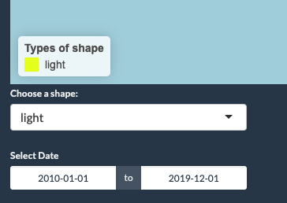

In addition to these, you can also determine duration by using the slider input on the right top of the map. This input explains the shape that you chose how long it had been seen.

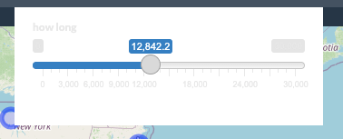

We also preferred to use **add legend** property in our leaflet code chunk for separated the shapes using different colors.

```
  color <- colorFactor(topo.colors(15), Data$shape)

  output$map <- leaflet::renderLeaflet({
  byduration() %>%
  leaflet() %>%
  addTiles() %>%
  setView( -98.58, 39.82, zoom = 5) %>%
  addTiles() %>%
  addCircleMarkers(popup = ~ comments, stroke=TRUE, fillOpacity=0.5,
                   color=~color(shape)
      ) %>%
      addLegend(
        "bottomleft", # Legend position
        pal=color, # color palette
        values=~shape, # legend values
        opacity = 1,
       title="Types of shape")
```

When you click on those shapes by mouse icon, you can see the popup comment including some information about the exact shape.

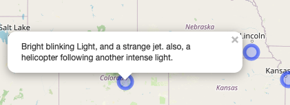

Now we are heading on our last tab panel which is actually including a **R Markdown** file. (also this HTML presentation ) This RMarkdown file aims mainly at the aspect of the shiny app besides some instructions about how you can use this app efficiently. And of course, you can also find information about the project, code and us.

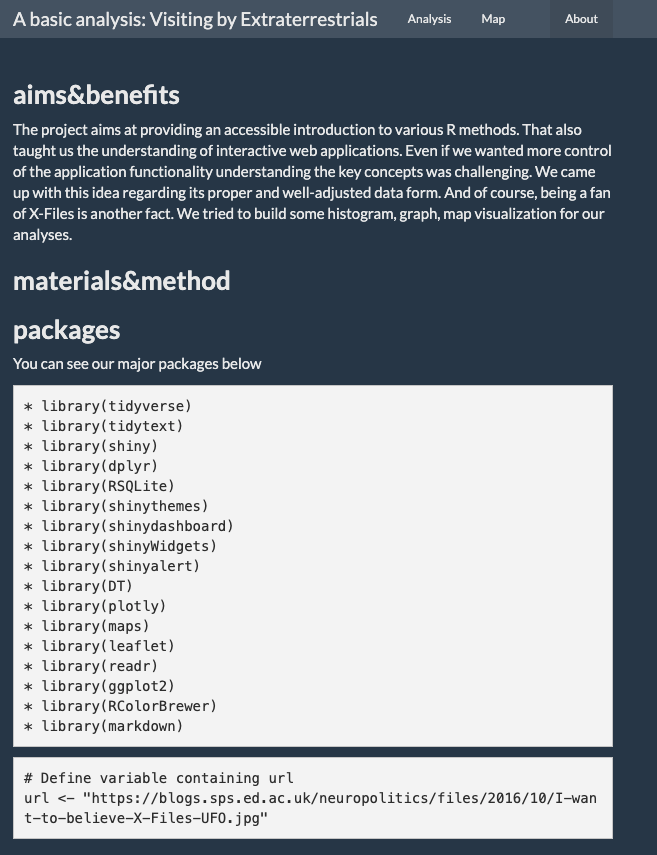

### **Thanks for your attention**

### **The truth is out there**